# Metric: measruing the distance between two distributions

Three metrics quantifying the differnece between two distributions.

Ming  
2021-12-12

In this blog, I’d introduce three metrics measruing the distance between two distributions.

# Kolmogorov–Smirnov test

The first metric is actually derived from a nonparametric method comparing the significant difference between two empirical distributions.

Let’s simulate some continuous distributed data first, and have a look at their empirical density plot and cumulative distributions.

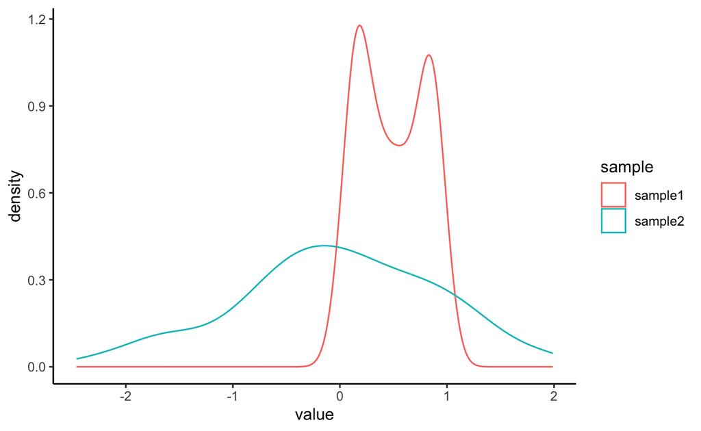

```r
library(ggplot2)
library(tidyverse)
set.seed(123456)
sample1=runif(100,0,1)
sample2=rnorm(200,0,1)

df=data.frame(sample=c(rep('sample1',100),rep('sample2',200)),
              value=c(sample1,sample2))
ggplot(df,aes(x=value,group=sample,col=sample))+
  geom_density()+theme_classic()
```

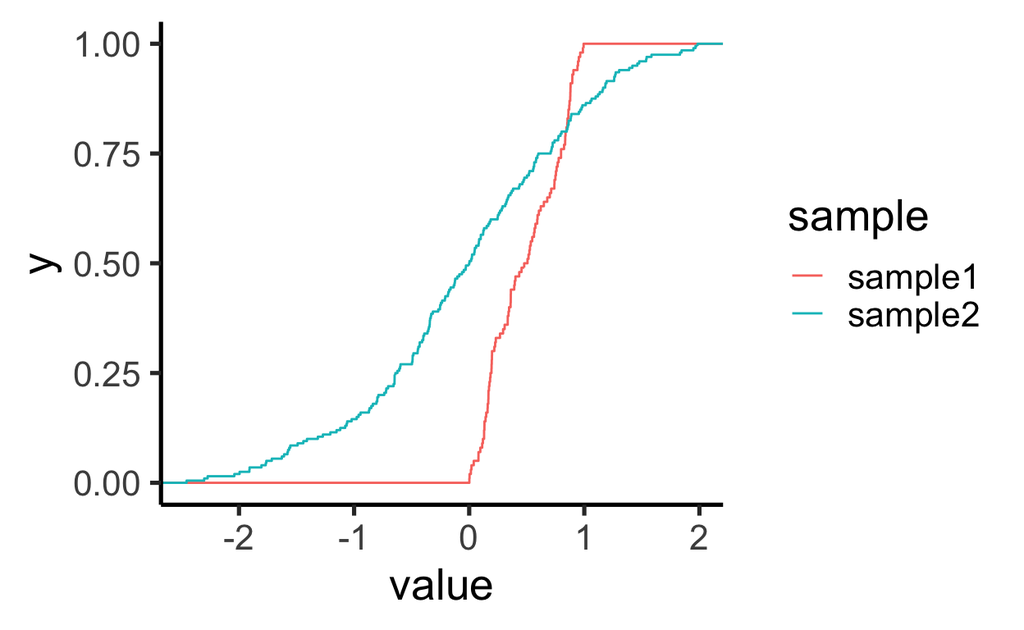

```r
ggplot(df, aes(x=value,group=sample,col=sample))+
  stat_ecdf(geom = "step")+theme_classic(base_size = 20)
```

```r
out=ks.test(sample1,sample2)
out$statistic
```

```
  D
0.5
```

The `statistic` reported by ks.test() is the largest distance between the two distributions.

We can explicitly visualize this statistic via code below.

```r
#Visualizing the Kolmogorov-Smirnov statistic in ggplot2
## ks: https://rpubs.com/mharris/KSplot
cdf1=ecdf(sample1)
cdf2=ecdf(sample2)

# find min and max statistics to draw line between points of greatest distance
minMax <- seq(min(sample1, sample2), max(sample1, sample2), length.out=length(sample1))
D= abs(cdf1(minMax) - cdf2(minMax))
max(D);
```

```
[1] 0.485
```

```r
out$statistic;
```

```
  D
0.5
```

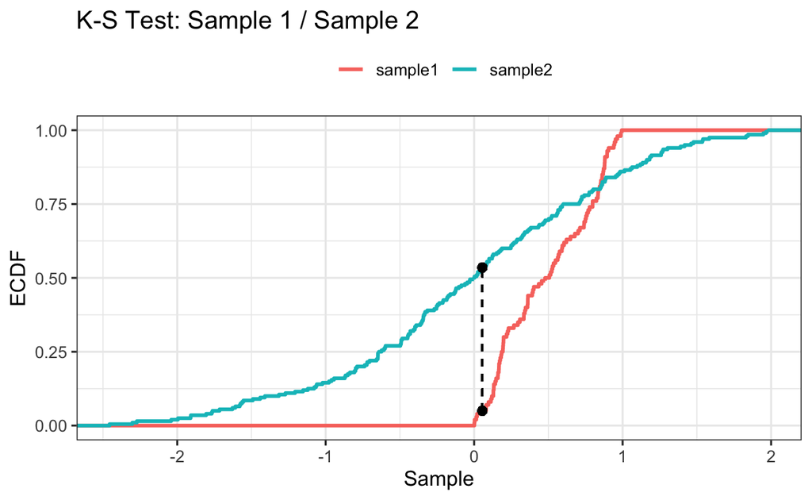

```r
x0 <- minMax[which(D== max(D))]
y0 <- cdf1(x0)
y1 <- cdf2(x0)
ggplot(df, aes(x = value, group = sample, color = sample))+
  stat_ecdf(size=1) +
  theme_bw(base_size = 12) +
  theme(legend.position ="top") +
  xlab("Sample") +
  ylab("ECDF") +
  geom_segment(aes(x = x0[1], y = y0[1], xend = x0[1], yend = y1[1]),
               linetype = "dashed", color = "black",lwd=0.5) +
  geom_point(aes(x = x0[1] , y= y0[1]), color="black", size=2) +
  geom_point(aes(x = x0[1] , y= y1[1]), color="black", size=2) +
  ggtitle("K-S Test: Sample 1 / Sample 2") +
  theme(legend.title=element_blank())
```

# Jensen–Shannon divergence

This **Jensen–Shannon divergence** is actually derived from **Kullback-Leibler Divergence**.

## the entorpy of a distribution

The core concept involved in this metric is **the entorpy of a distribution**.

The definition of Entropy for a probability distribution is:

$$H=-\sum_{i=1}^{N} p(x_i)*log(p(x_i))$$
If we use $log2$ in the above calculation, it can be interpreted as ‘the minimal number of bits to encode the information’.

A simplest example, if we have a coin with head probability 0.5 and tail probability 0.5, then $H = -1*{(0.5*log2(0.5) + 0.5*log2(0.5)}=1$, which means we need 1 bit to encode the fairness of this coin.

Suppose, this coin is unfair, with head = 0.8 and tail = 0.2. Then $H = -1*{(0.8*log2(0.8) + 0.2*log2(0.2)}=0.7219$.

Entropy can be interpreted as the **uncertainty** of a distribution. It’s more difficult or it invovoles more uncertainty to predict what the next outcome would be with a fair coin than with a unfair coin. Thus, a fair coin requires more bit to encode its information.

## Kullback-Leibler Divergence

The KL divergence formula is:

$$D_{KL}(p||q)=\sum_{i=1}^N p(x_i)*(log p(x_i) - log q(x_i))$$

or
$$D_{KL}(p||q)=E[log p(x_i) - log q(x_i)]$$
or
$$D_{KL}(p||q)=\sum_{i=1}^N p(x_i) * log\frac{p(x_i)}{q(x_i)}$$
We can use functions from R package `philentropy` to do the calculation.

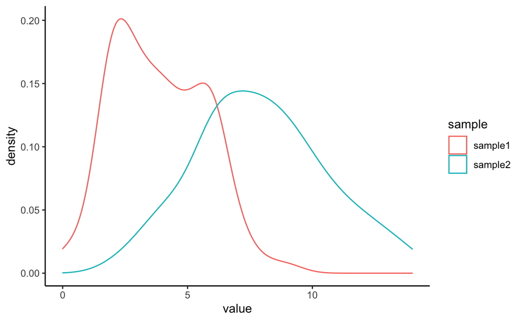

```r
set.seed(123456)
sample1=rbinom(100,20,0.2)
sample2=rpois(200,8)
df=data.frame(sample=c(rep('sample1',100),rep('sample2',200)),
              value=c(sample1,sample2))

ggplot(df, aes(x=value,group=sample,col=sample))+
  geom_density()+theme_classic()
```

```r
f1=prop.table(table(sample1))
f2=prop.table(table(sample2))
bins=sort(as.numeric(unique(c(names(f1),names(f2)))))
tmp=rep(0,length(bins))
names(tmp)=bins
s1=tmp
s1[names(f1)]=f1;
s2=tmp
s2[names(f2)]=f2;
rbind(s1,s2)
```

```
      0    1    2    3    4     5    6     7     8    9    10    11
s1 0.02 0.03 0.25 0.17 0.16 0.130 0.18 0.040 0.010 0.01 0.000 0.000
s2 0.00 0.00 0.01 0.03 0.06 0.065 0.15 0.145 0.145 0.13 0.095 0.065
     12    13   14
s1 0.00 0.000 0.00
s2 0.05 0.035 0.02
```

```r
# unsymmetric
philentropy::KL(rbind(s1,s2),unit = 'log2')
```

```
kullback-leibler
        2.406076
```

```r
philentropy::KL(rbind(s2,s1),unit = 'log2')
```

```
kullback-leibler
        4.323369
```

As you may have notice, one thing with KL divergence is, it’s not symmetric. So, here comes Jensen-Shannon Divergence.

## Jensen-Shannon Divergence

JSD is defined as:

$$JSD(P||Q) = 0.5 * (KL(P||R)+KL(Q||R))$$

$R = 0.5 * (P+Q)$

We can use `JSD` function to do the calculation.

```r
R = 0.5*(s1+s2)
0.5*(philentropy::KL(rbind(s1,R),unit = 'log2')+
  philentropy::KL(rbind(s2,R),unit = 'log2'))
```

```
kullback-leibler
       0.4394997
```

```r
philentropy::JSD(rbind(s2,s1),unit='log2')
```

```
jensen-shannon
     0.4394997
```

```r
philentropy::JSD(rbind(s1,s2),unit='log2')
```

```
jensen-shannon
     0.4394997
```

# Optimal Transport and Wasserstein Distance

[Wasserstein Distance](https://en.wikipedia.org/wiki/Wasserstein_metric) has a nickname of [Earth mover’s distance](https://en.wikipedia.org/wiki/Earth_mover%27s_distance), i.e., what’s the minimal effort you have to do to move a pile of sand from region A to region B.

While there are more math involved for this metric, it is very popular in single-cell data methodology development.

I would only show the function used in R to calculate this metric.

```r
set.seed(123456)
sample1=runif(100,0,1)
sample2=rnorm(200,0,1)

transport::wasserstein1d(sample1,sample2)
```

```
[1] 0.6560769
```

```r
set.seed(123456)
sample1=rbinom(100,20,0.2)
sample2=rpois(200,8)
transport::wasserstein1d(sample1,sample2)
```

```
[1] 4.06
```

Have fun~